# Final Project

## Due 11:59pm, Tuesday, December 8, 2020

You are required to work in **groups of 2~3 members** (you can continue with your teams in the midterm project). Please include the **names** and **student ID (ASU network ID)** of all teambers. **Only team leader needs to submit required documents**.

The task is similar to that of Midterm Project: work on project of your choice, but this time you need to do it in Python. It is okay to take your topic in Project 1 and do programming in Python, as long as you also upgrade it (for example, answer more questions than you did in the midterm). Furthermore, you can even do some of the previous labs, as long as you convert them into Python, **and broaden or deepen the analysis**. I do not expect as much of complicated coding as in Midterm Project, since we did not cover Python as much as we did R.

You should include some plots (for example, using matplotlib library) as well as some data manipulation with pandas.

You can create Python script files (.py), but you should also have a report in Jupyter notebook, i.e. ipynb file.

Apart from ipynb file, you also need to upload html and pdf versions of it. You can do this in two ways.

One way, when you have your ipynb open in Jupyter, go to **File $\rightarrow$ Download as $\rightarrow$ HTML (.html)**. Once you create html file, your internet browser should be able to convert html to pdf (at least Google Chrome does that).

Alternativaly, to convert ipynb to html and pdf, open Anaconda prompt. Then, in the prompt, if converting into html, type

`jupyter nbconvert --to html file_name_with_full_path`

For example, if I want to convert my file final.ipynb into html, which is located in the folder **/Users/slan/Teaching/ASU/DAT301/Projects/Final.ipynb**, I would type

`jupyter nbconvert --to html /Users/slan/Teaching/ASU/DAT301/Projects/Final.ipynb`

NOTE: If a folder in the path has name that includes blank space, you would either need to rename the folder or else: first change current working directory where the file is, and then use the above command, but only with the file name (including extension). For example, if I am currently in the folder

`(base) slan@XXX ~ %`

`cd ~/Teaching/ASU/DAT301`

Then, to convert my Jupyter notebook `Final.ipynb` (which is now in the current directory) into html, I type

`jupyter nbconvert --to html Final.ipynb`

To convert ipynb file into pdf, you do the same as above, but replace word "html" with "pdf".

# IMPORTANT:

## Make sure you meet the following requirements and obey the rules given below

- Copying a project from someone or some webpage is cheating and violates academic integrity! This automatically results in the score of 0 pts on the final, and other possible sanctions include, but are not limited to: course failure (indicated on the transcript as a grade of E), course failure due to academic dishonesty (indicated on the transcript as a grade of XE), loss of registration privileges, disqualification and dismissal. For more information, please see http://provost.asu.edu/academicintegrity.
- You MUST cite all the sources. In particular, you have to include webpage where you got data from, as well as the authors (if applicable).
- You MUST submit **(1)ipynb and (2) html or pdf files** for the project. If any data source files are needed to reproduce your results, put them in the cloud (e.g. Google Drive, Dropbox) and include the link in the submitted files. Do NOT zip the files into one folder. They should be unzipped.
- You MUST submit ALL the outputs (plots, graphs, etc.) if they are not generated by matplotlib or seaborn and cannot by be embbed in the jupyter notebook.
- You MUST submit a presentation in the form of ipynb file, as well as its html OR pdf versions.
- Upon submission, you MUST stay safe and have a nice break! :-)

### Here are some Examples to start with.

```python
# Import necessary libraries
import numpy as np
np.set_printoptions(precision=4, suppress=True)
np.random.seed(2020)
import pandas as pd
pd.options.display.max_rows = 20
import matplotlib.pyplot as plt
```

```python
#this enables interactive use of matplotlib
##%matplotlib notebook
%matplotlib inline
```

### Plot random walk

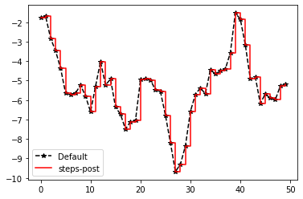

```python
data = np.random.randn(50).cumsum()
plt.plot(data, 'k*--', label='Default')
plt.plot(data, 'r-', drawstyle='steps-post', label='steps-post')
plt.legend(loc='best')   #see also plt.legend(loc='best')
```

### Present table

```python
df = pd.DataFrame(np.random.rand(100, 4),
                  index=np.arange(100),
                  columns=pd.Index(['A', 'B', 'C', 'D'], name='Genus'))
df
```

| Genus | A | B | C | D |
| --- | --- | --- | --- | --- |
| 0 | 0.290672 | 0.682960 | 0.285180 | 0.659579 |
| 1 | 0.723604 | 0.240346 | 0.408367 | 0.069885 |
| 2 | 0.699445 | 0.285477 | 0.885452 | 0.315771 |
| 3 | 0.687254 | 0.410304 | 0.446182 | 0.824733 |
| 4 | 0.065148 | 0.925143 | 0.363251 | 0.278779 |
| ... | ... | ... | ... | ... |
| 95 | 0.058187 | 0.508651 | 0.519862 | 0.059369 |
| 96 | 0.170374 | 0.948786 | 0.944187 | 0.731175 |
| 97 | 0.865653 | 0.489804 | 0.202528 | 0.166416 |
| 98 | 0.132226 | 0.740689 | 0.847019 | 0.688022 |
| 99 | 0.368563 | 0.878720 | 0.153236 | 0.251801 |

100 rows × 4 columns

### Pairwise Density plot

```python
%%html
<style>
.output_wrapper, .output {
    height:auto !important;
    max-height:1000px;  /* your desired max-height here */
}
.output_scroll {
    box-shadow:none !important;
    webkit-box-shadow:none !important;
}
</style>
```

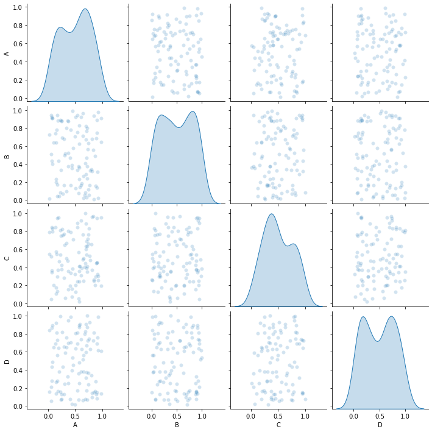

```python
import seaborn as sns

sns.pairplot(df, diag_kind='kde', plot_kws={'alpha': 0.2})
```